# Differential InSAR using GAMMA Tutorial

Written by Nicholas Pontone (2024)

This tutorial will walkthrough the steps required to create an interferogram and create coherence products using 2-pass differential interferometry. Before starting, please ensure that this notebook is located in your working directory, as files will automatically be output to the folder it contains. This tutorial includes the use of many GAMMA tools and functions, and they will not all be fully explained. For more information about a particular tool, open "MSYS MINGW64", type "gamma_doc" into the command line, and the GAMMA documentation will open. The "program list" contains documentation for all of the tools used.

```python
#Script to create an interferogram (from two S1 SLC images) using GAMMA

#Import dependencies
import sys
sys.path.insert(0, 'C:/GAMMA_SOFTWARE-20240111')
import py_gamma as pg
import matplotlib.pyplot as plt
import numpy as np
import glob

%matplotlib inline
```

```python
#Set working directory
Outputdir = "E:/AlfredInSAR3"
```

# Data Management and Preprocessing

Here, we are going to read in our Sentinel-1 Interferometric Wide data and create all the necessary parameter files required for GAMMA.

In this analysis, we are going to use two-pass differential interferometry. This requires two images, one before the deformation event and and one after.

Required Data:

- Two Sentinel-1 IW SLC images. Images can be downloaded from Alaska Satellite Facility or Copernicus Hub. The folders containing the data must be unzipped and located in the working directory.
- SRTM (or other DEM) that completely covers the area of the image you plan to use as your reference image (typically the image captured earlier in time). This must be in .tif format, and heights must be related to WGS 84

Within the working directory you need three folders:

- slc_TOPS (empty at the start of processing)
- slc_TOPS_deramp (empty at the start of processing)
- DEM (contains your DEM file)

Note that if you choose to follow this tutorial with different imagery, every time there is a date ("ex. 20210503"), it must be changed to match your image.

```python
#Create a parameter file for the first image
measurement = "E:/AlfredInSAR3/S1/S1A_IW_SLC__1SDV_20180916T225220_20180916T225247_023730_02965B_26C4.SAFE/measurement/s1a-iw2-slc-vv-20180916t225221-20180916t225247-023730-02965b-005.tiff"

annotation = "E:/AlfredInSAR3/S1/S1A_IW_SLC__1SDV_20180916T225220_20180916T225247_023730_02965B_26C4.SAFE/annotation/s1a-iw2-slc-vv-20180916t225221-20180916t225247-023730-02965b-005.xml"

calibration = "E:/AlfredInSAR3/S1/S1A_IW_SLC__1SDV_20180916T225220_20180916T225247_023730_02965B_26C4.SAFE/annotation/calibration/calibration-s1a-iw2-slc-vv-20180916t225221-20180916t225247-023730-02965b-005.xml"
noise = "E:/AlfredInSAR3/S1/S1A_IW_SLC__1SDV_20180916T225220_20180916T225247_023730_02965B_26C4.SAFE/annotation/calibration/noise-s1a-iw2-slc-vv-20180916t225221-20180916t225247-023730-02965b-005.xml"

ISP_Out = Outputdir + "\slc_TOPS" + "\IW1.20180916.slc.par"
SLC_Out = Outputdir + "\slc_TOPS" + "\IW1.20180916.slc"
TOP_Out = Outputdir + "\slc_TOPS" + "\IW1.20180916.slc.TOPS_par"

pg.par_S1_SLC(measurement,annotation,calibration,noise,ISP_Out, SLC_Out, TOP_Out, 1)
```

```
cmd: C:\GAMMA_SOFTWARE-20240111\ISP\bin\par_S1_SLC E:/AlfredInSAR3/S1/S1A_IW_SLC__1SDV_20180916T225220_20180916T225247_023730_02965B_26C4.SAFE/measurement/s1a-iw2-slc-vv-20180916t225221-20180916t225247-023730-02965b-005.tiff E:/AlfredInSAR3/S1/S1A_IW_SLC__1SDV_20180916T225220_20180916T225247_023730_…

*** Generate SLC parameter and image files for Sentinel-1 SLC data ***
*** Copyright 2023, Gamma Remote Sensing, v5.5 06-Dec-2023 awi/clw/cm ***
GeoTIFF data set: E:/AlfredInSAR3/S1/S1A_IW_SLC__1SDV_20180916T225220_20180916T225247_023730_02965B_26C4.SAFE/measurement/s1a-iw2-slc-vv-20180916t225221-20180916t225247-023730-02965b-005.tiff
GeoTIFF basename: s1a-iw2-slc-vv-20180916t225221-20180916t225247-023730-02965b-005.tiff
GDAL driver: GTiffGeoTIFF
SLC image size: X, Y, Z: 25745x13590x1
GeoTIFF software version: Sentinel-1 IPF 002.91
S1 XML annotation: E:/AlfredInSAR3/S1/S1A_IW_SLC__1SDV_20180916T225220_20180916T225247_023730_02965B_26C4.SAFE/annotation/s1a-iw2-slc-vv-20180916t225221-20180916t225247-023730-02965b-005.xml
S1 XML calibration LUT: E:/AlfredInSAR3/S1/S1A_IW_SLC__1SDV_20180916T225220_20180916T225247_023730_02965B_26C4.SAFE/annotation/calibration/calibration-s1a-iw2-slc-vv-20180916t225221-20180916t225247-023730-02965b-005.xml
number of lines in the Sentinel-1 calibration LUT file: 281
S1 XML noise LUT: E:/AlfredInSAR3/S1/S1A_IW_SLC__1SDV_20180916T225220_20180916T225247_023730_02965B_26C4.SAFE/annotation/calibration/noise-s1a-iw2-slc-vv-20180916t225221-20180916t225247-023730-02965b-005.xml
number of lines in the Sentinel-1 noise LUT file: 94
SLC output data format: SCOMPLEX
number of lines in the Sentinel-1 annotation file: 5152
scale factor (FCOMPLEX to SCOMPLEX) dB: 60.0000   magnitude: 1000.0000sensor: S1A IW IW2 VV
absoluteOrbitNumber: 23730
SLC image first line UTC time stamp: 2018 9 16 22 52 21.915969   seconds of day: 82341.915969
SLC image last line UTC time stamp: 2018 9 16 22 52 47.0842   seconds of day: 82367.084200
GeoTIFF image data format: 16 bit Signed Integer Complex
orbit ascending node time:: 2018 9 16 22 40 10.745474   seconds of day: 81610.745474
azimuth steering rate (deg/s): -0.97986332
azimuth line time interval (s): 2.05555630e-03
effective PRF calculated from azimuth line time interval (Hz): 486.486310
calculating SLC end time from azimuth time interval: 82367.084200
number of state vectors: 17
read the state vectors that cover the image (+/- 60 sec): 82281.9160   82427.0842
timeStamp  1: 2018 9 16 22 51    15.3705990 82275.3705990
timeStamp  1: 2018 9 16 22 51    25.3705990 82285.3705990
timeStamp  2: 2018 9 16 22 51    35.3705980 82295.3705980
timeStamp  3: 2018 9 16 22 51    45.3705980 82305.3705980
timeStamp  4: 2018 9 16 22 51    55.3705990 82315.3705990
timeStamp  5: 2018 9 16 22 52     5.3705990 82325.3705990
timeStamp  6: 2018 9 16 22 52    15.3705980 82335.3705980
timeStamp  7: 2018 9 16 22 52    25.3705980 82345.3705980
timeStamp  8: 2018 9 16 22 52    35.3705990 82355.3705990
timeStamp  9: 2018 9 16 22 52    45.3705990 82365.3705990
timeStamp 10: 2018 9 16 22 52    55.3705980 82375.3705980
timeStamp 11: 2018 9 16 22 53     5.3705980 82385.3705980
```

[output cut: 490 more lines]

```

line:       0
line:    2000
line:    4000
line:    6000
line:    8000
line:   10000
line:   12000

SLC file: E:/AlfredInSAR3\slc_TOPS\IW1.20180916.slc
SLC parameter file:   E:/AlfredInSAR3\slc_TOPS\IW1.20180916.slc.par
TOPS annotation file: E:/AlfredInSAR3\slc_TOPS\IW1.20180916.slc.TOPS_par
SLC width: 25745   lines: 13590

real elapsed time (s):      6.687
```

```
0
```

```python
#Create a parameter file for the second image
measurement2 = "E:/AlfredInSAR3/S1/S1A_IW_SLC__1SDV_20180928T225220_20180928T225247_023905_029C08_83E8.SAFE/measurement/s1a-iw2-slc-vv-20180928t225222-20180928t225247-023905-029c08-005.tiff"

annotation2 = "E:/AlfredInSAR3/S1/S1A_IW_SLC__1SDV_20180928T225220_20180928T225247_023905_029C08_83E8.SAFE/annotation/s1a-iw2-slc-vv-20180928t225222-20180928t225247-023905-029c08-005.xml"

calibration2 = "E:/AlfredInSAR3/S1/S1A_IW_SLC__1SDV_20180928T225220_20180928T225247_023905_029C08_83E8.SAFE/annotation/calibration/calibration-s1a-iw2-slc-vv-20180928t225222-20180928t225247-023905-029c08-005.xml"
noise2 = "E:/AlfredInSAR3/S1/S1A_IW_SLC__1SDV_20180928T225220_20180928T225247_023905_029C08_83E8.SAFE/annotation/calibration/noise-s1a-iw2-slc-vv-20180928t225222-20180928t225247-023905-029c08-005.xml"

ISP_Out2 = Outputdir + "\slc_TOPS" + "\IW1.20180928.slc.par"
SLC_Out2 = Outputdir + "\slc_TOPS" + "\IW1.20180928.slc"
TOP_Out2 = Outputdir + "\slc_TOPS" + "\IW1.20180928.slc.TOPS_par"

pg.par_S1_SLC(measurement2,annotation2,calibration2,noise2,ISP_Out2, SLC_Out2, TOP_Out2, 1)
```

```
cmd: C:\GAMMA_SOFTWARE-20240111\ISP\bin\par_S1_SLC E:/AlfredInSAR3/S1/S1A_IW_SLC__1SDV_20180928T225220_20180928T225247_023905_029C08_83E8.SAFE/measurement/s1a-iw2-slc-vv-20180928t225222-20180928t225247-023905-029c08-005.tiff E:/AlfredInSAR3/S1/S1A_IW_SLC__1SDV_20180928T225220_20180928T225247_023905_…

*** Generate SLC parameter and image files for Sentinel-1 SLC data ***
*** Copyright 2023, Gamma Remote Sensing, v5.5 06-Dec-2023 awi/clw/cm ***
GeoTIFF data set: E:/AlfredInSAR3/S1/S1A_IW_SLC__1SDV_20180928T225220_20180928T225247_023905_029C08_83E8.SAFE/measurement/s1a-iw2-slc-vv-20180928t225222-20180928t225247-023905-029c08-005.tiff
GeoTIFF basename: s1a-iw2-slc-vv-20180928t225222-20180928t225247-023905-029c08-005.tiff
GDAL driver: GTiffGeoTIFF
SLC image size: X, Y, Z: 25745x13590x1
GeoTIFF software version: Sentinel-1 IPF 002.91
S1 XML annotation: E:/AlfredInSAR3/S1/S1A_IW_SLC__1SDV_20180928T225220_20180928T225247_023905_029C08_83E8.SAFE/annotation/s1a-iw2-slc-vv-20180928t225222-20180928t225247-023905-029c08-005.xml
S1 XML calibration LUT: E:/AlfredInSAR3/S1/S1A_IW_SLC__1SDV_20180928T225220_20180928T225247_023905_029C08_83E8.SAFE/annotation/calibration/calibration-s1a-iw2-slc-vv-20180928t225222-20180928t225247-023905-029c08-005.xml
number of lines in the Sentinel-1 calibration LUT file: 281
S1 XML noise LUT: E:/AlfredInSAR3/S1/S1A_IW_SLC__1SDV_20180928T225220_20180928T225247_023905_029C08_83E8.SAFE/annotation/calibration/noise-s1a-iw2-slc-vv-20180928t225222-20180928t225247-023905-029c08-005.xml
number of lines in the Sentinel-1 noise LUT file: 88
SLC output data format: SCOMPLEX
number of lines in the Sentinel-1 annotation file: 5152
scale factor (FCOMPLEX to SCOMPLEX) dB: 60.0000   magnitude: 1000.0000sensor: S1A IW IW2 VV
absoluteOrbitNumber: 23905
SLC image first line UTC time stamp: 2018 9 28 22 52 22.148896   seconds of day: 82342.148896
SLC image last line UTC time stamp: 2018 9 28 22 52 47.3171   seconds of day: 82367.317127
GeoTIFF image data format: 16 bit Signed Integer Complex
orbit ascending node time:: 2018 9 28 22 40 10.979157   seconds of day: 81610.979157
azimuth steering rate (deg/s): -0.97986332
azimuth line time interval (s): 2.05555630e-03
effective PRF calculated from azimuth line time interval (Hz): 486.486310
calculating SLC end time from azimuth time interval: 82367.317127
number of state vectors: 17
read the state vectors that cover the image (+/- 60 sec): 82282.1489   82427.3171
timeStamp  1: 2018 9 28 22 51    15.6011410 82275.6011410
timeStamp  1: 2018 9 28 22 51    25.6011410 82285.6011410
timeStamp  2: 2018 9 28 22 51    35.6011400 82295.6011400
timeStamp  3: 2018 9 28 22 51    45.6011400 82305.6011400
timeStamp  4: 2018 9 28 22 51    55.6011410 82315.6011410
timeStamp  5: 2018 9 28 22 52     5.6011410 82325.6011410
timeStamp  6: 2018 9 28 22 52    15.6011400 82335.6011400
timeStamp  7: 2018 9 28 22 52    25.6011400 82345.6011400
timeStamp  8: 2018 9 28 22 52    35.6011410 82355.6011410
timeStamp  9: 2018 9 28 22 52    45.6011410 82365.6011410
timeStamp 10: 2018 9 28 22 52    55.6011400 82375.6011400
timeStamp 11: 2018 9 28 22 53     5.6011400 82385.6011400
```

[output cut: 490 more lines]

```

line:       0
line:    2000
line:    4000
line:    6000
line:    8000
line:   10000
line:   12000

SLC file: E:/AlfredInSAR3\slc_TOPS\IW1.20180928.slc
SLC parameter file:   E:/AlfredInSAR3\slc_TOPS\IW1.20180928.slc.par
TOPS annotation file: E:/AlfredInSAR3\slc_TOPS\IW1.20180928.slc.TOPS_par
SLC width: 25745   lines: 13590

real elapsed time (s):      5.511
```

```
0
```

```python
#Write .txt files that contain the names of our parameter files.
#These are needed as inputs for scripts/programs.

prefix = "IW1.20180928" #Change the prefix each time you run this, should be once for each image you're using.

column1 = Outputdir + '/' +  "/slc_TOPS" + '/'+ prefix + ".slc"
column2 = Outputdir + '/' + "/slc_TOPS" + '/'+ prefix + ".slc.par"
column3 = Outputdir + '/' + "/slc_TOPS" + '/'+ prefix + ".slc.TOPS_par"

# Open a file in write mode
with open(Outputdir + "\\" + prefix + ".SLC_tab", "w") as f:
    # Write the strings for each column separated by tabs
    f.write(f"{column1}\t{column2}\t{column3}\n")


print("Wrote to " + Outputdir + "\\" + prefix + ".SLC_tab")
```

```python
#Now we need to make a table to contain the information when we deramp the azimuth phase from the images. These are stored in their own folder, as GAMMA likes to
#overwrite files with the same name.

prefix = "IW1.20180916" #Change the prefix each time you run this, should be once for each image you're using.

column1 = Outputdir + '/'  + "/slc_TOPS_deramp" + '/'+ prefix + ".slc"
column2 = Outputdir + '/'  + "/slc_TOPS_deramp" + '/'+ prefix + ".slc.par"
column3 = Outputdir + '/'  + "/slc_TOPS_deramp"+ '/'+ prefix + ".slc.TOPS_par"

# Open a file in write mode
with open(Outputdir + "\\" + prefix + ".deramp" + ".SLC_tab", "w") as f:
    # Write the strings for each column separated by tabs
    f.write(f"{column1}\t{column2}\t{column3}\n")


print("Wrote to " + Outputdir + "\\" + prefix + ".deramp" + ".SLC_tab")
```

To facilitate coregistration, the reference (master) image must be geocoded (precisely aligned in a geographic coordinate system). The lookup tables and height maps created for geocoding are also used in the coregistration process.

Generate the SLC mosaics. The number of range looks (10) and azimuth looks (2) is indicated to assure that the cutting between bursts and sub-swaths is done such that multi-looking will not mix pixels from different subwaths or bursts.

```python
# SLC data comes as seperated bursts. This function will 'deburst' the imagery, combining them into a continuous mosaic.
pg.SLC_mosaic_ScanSAR('IW1.20180916.SLC_tab', '20180916.slc', '20180916.slc.par', 10, 2, 1) #We change the filename here because it will overwrite itself and break otherwise. Also we don't want to delete the original image parameters.
pg.SLC_mosaic_ScanSAR('IW1.20180928.SLC_tab', '20180928.slc', '20180928.slc.par', 10, 2, 1)
```

```
cmd: C:\GAMMA_SOFTWARE-20240111\ISP\bin\SLC_mosaic_ScanSAR IW1.20180916.SLC_tab 20180916.slc 20180916.slc.par 10 2 1

*** Calculate SLC mosaic of ScanSAR SLC burst data (Sentinel-1, TerraSAR-X, RCM...) ***
*** Copyright 2023, Gamma Remote Sensing v4.9 5-Sep-2023 clw/awi/cm ***

OPENMP: number of physical processors:                     32
OPENMP: default max. number of threads (program specific): 8
OPENMP: current max. number of available threads:          32
OPENMP: number of program threads: 8


SLC_tab: IW1.20180916.SLC_tab
output SLC mosaic: 20180916.slc   file number: 4
range looks used to determine burst data window:   10
azimuth looks used to determine burst data window: 2
output SLC mosaic image: 20180916.slc
output SLC mosaic parameter file: 20180916.slc.par

NOTE: calculating burst window parameters from burst parameters
number of input SLC images: 1
ScanSAR SLC file: E:/AlfredInSAR3//slc_TOPS/IW1.20180916.slc
SLC parameter file: E:/AlfredInSAR3//slc_TOPS/IW1.20180916.slc.par
ScanSAR burst parameter file: E:/AlfredInSAR3//slc_TOPS/IW1.20180916.slc.TOPS_par
r0 (m): 846662.613  r2 (m): 906634.857  nr: 25745  rpix (m):  2.329562  t0 (s): 82341.915969  t2 (s): 82367.084200  nlines:  13590  time_per_line (s): 2.055556e-03
SLC mosaic date year: 2018  month: 09  day: 16
SLC mosaic when not resampled to reference SLC range samples: 25745   lines: 12245

SLC input data format:  SCOMPLEX   bytes/sample: 4

radar position at center time 82354.50008, x,y,z (m):    780807.072  -4968111.241   4968482.752
scene center latitude (deg.): 45.77408618   longitude (deg.): -74.85120782
scene center earth radius (m): 6367300.636  incidence angle at scene center from state vectors (deg.): 39.075790
earth radius below sensor (m): 7069484.411  platform heading (deg.): -14.254159

SLC mosaic data format: SCOMPLEX
SLC mosaic range sample spacing (m):      2.32956
SLC mosaic azimuth sample spacing (m):   13.90934
SLC mosaic range samples: 25745
SLC mosaic azimuth lines: 12245
SLC mosaic file size (bytes): 1260990100   Mb: 1202.574
```

[output cut: 267 more lines]

```
SLC: 1   burst:  2   burst window:  846662.6127   906623.2090    82345.08012    82347.83662  bw.ir0:     0   bw.nrs: 25740   bw.iaz0:    84  bw.naz:  1342
SLC: 1   burst:  3   burst window:  846662.6127   906623.2090    82347.83868    82350.59518  bw.ir0:     0   bw.nrs: 25740   bw.iaz0:    84  bw.naz:  1342
SLC: 1   burst:  4   burst window:  846662.6127   906623.2090    82350.59723    82353.35373  bw.ir0:     0   bw.nrs: 25740   bw.iaz0:    84  bw.naz:  1342
SLC: 1   burst:  5   burst window:  846662.6127   906623.2090    82353.35579    82356.11229  bw.ir0:     0   bw.nrs: 25740   bw.iaz0:    85  bw.naz:  1342
SLC: 1   burst:  6   burst window:  846662.6127   906623.2090    82356.11435    82358.87085  bw.ir0:     0   bw.nrs: 25740   bw.iaz0:    85  bw.naz:  1342
SLC: 1   burst:  7   burst window:  846662.6127   906623.2090    82358.87290    82361.62529  bw.ir0:     0   bw.nrs: 25740   bw.iaz0:    86  bw.naz:  1340
SLC: 1   burst:  8   burst window:  846662.6127   906623.2090    82361.62735    82364.38385  bw.ir0:     0   bw.nrs: 25740   bw.iaz0:    84  bw.naz:  1342
SLC: 1   burst:  9   burst window:  846662.6127   906623.2090    82364.38590    82367.31507  bw.ir0:     0   bw.nrs: 25740   bw.iaz0:    83  bw.naz:  1426
writing output SLC buffer: 3  lines:   3185  width:  25745  samples: 81997825

output SLC range samples: 25745  azimuth lines: 12245
output SLC mosaic image:   20180928.slc
output SLC parameter file: 20180928.slc.par

real elapsed time (s):      0.749
```

```
0
```

```python
#Create multilook intensity image (Phase and amplitude).
pg.multi_look('20180916.slc', '20180916.slc.par', '20180916.slc.mli', '20180916.slc.mli.par', 10, 2, 1, '-', 0.000001) #Using range looks (10) and azimuth looks (2) ensures pixels between bursts will not be mixed.
pg.multi_look('20180928.slc', '20180928.slc.par', '20180928.slc.mli', '20180928.slc.mli.par', 10, 2, 1, '-', 0.000001)
```

```
cmd: C:\GAMMA_SOFTWARE-20240111\ISP\bin\multi_look 20180916.slc 20180916.slc.par 20180916.slc.mli 20180916.slc.mli.par 10 2 1 - 1e-06

*** Calculate a multi-look intensity (MLI) image from an SLC image ***
*** Copyright 2022, Gamma Remote Sensing, v4.7 8-Aug-2022 clw/uw/cm ***
OPENMP: number of physical processors:                     32
OPENMP: default max. number of threads (program specific): 6
OPENMP: current max. number of available threads:          32
OPENMP: number of program threads: 6

SLC file: 20180916.slc
SLC parameter file: 20180916.slc.par
MLI file: 20180916.slc.mli
MLI parameter file: 20180916.slc.mli.par
radar sensor: S1A IW IW2 VV

NOTE: retaining incidence angle at image center for entire SLC image frame
NOTE: retaining doppler parameters for entire SLC image frame

SLC format: scomplex (pairs of 2-byte integer (re,im))
range looks:                  10
azimuth looks:                 2
offset to starting line:       1
number of lines:           12244
relative output scale factor: 0.000001
output exponent: 1.000000

SLC title:                      s1a-iw2-slc-vv-20180916t225221-20180916t225247-023730-02965b-005.tiff S1A-IW-IW2-VV-23730 (software: Sentinel-1 IPF 002.91)
input line header size (bytes):          0
SLC range sample spacing (m):      2.32956
SLC azimuth sample spacing (m):   13.90934
SLC image range samples:             25745
SLC image azimuth lines:             12245

MLI range sample spacing (m):     23.29562
MLI azimuth sample spacing (m):   27.81868
MLI image range samples:              2574
MLI image azimuth lines:              6122

multi-look output line:      0
multi-look output line:   2000
```

[output cut: 41 more lines]

```

MLI range sample spacing (m):     23.29562
MLI azimuth sample spacing (m):   27.81864
MLI image range samples:              2574
MLI image azimuth lines:              6122

multi-look output line:      0
multi-look output line:   2000
multi-look output line:   4000
multi-look output line:   6000

output MLI file: 20180928.slc.mli
width: 2574  lines: 6122

real elapsed time (s):      1.253
```

```
0
```

At several stages, you should be looking at the results. Both to understand what is happening in the processing, and to ensure that everything is proceeding as expected. At several key stages we will be using the "raspwr" function to convert results to .bmp for easy visualization.

```python
pg.raspwr('20180916.slc.mli', 2574, '-', '-', '-', '-', '-', '-', '-', '20180916.slc.mli.bmp')
pg.raspwr('20180928.slc.mli', 2574, '-', '-', '-', '-', '-', '-', '-', '20180928.slc.mli.bmp')
```

```
cmd: C:\GAMMA_SOFTWARE-20240111\DISP\bin\raspwr 20180916.slc.mli 2574 - - - - - - - 20180916.slc.mli.bmp

*** DISP Program C:\GAMMA_SOFTWARE-20240111\DISP\bin\raspwr ***
*** Copyright 2023, Gamma Remote Sensing, v1.7 19-Apr-2023 clw/cm ***
*** Calculate a raster image from data (FLOAT or UNSIGNED SHORT) with power-law scaling using a specified colormap ***
OPENMP: number of physical processors:                     32
OPENMP: default max. number of threads (program specific): 6
OPENMP: current max. number of available threads:          32
OPENMP: number of program threads: 6

input data filename: 20180916.slc.mli
data type: FLOAT
power-law display scale: 1.0000  exponent: 0.3500
DISP_HOME: C:\GAMMA_SOFTWARE-20240111\DISP
default colormap: gray.cm
default colormap path: C:\GAMMA_SOFTWARE-20240111\DISP/cmaps/gray.cm
number of colormap entries: 256
input data image width: 2574   height: 6122
starting line offset: 0
pixavx: 1   pixavy: 1
average intensity:   1.14680e-01  dB: -9.4051
power-law rel. scale: 1.000  exponent:0.3500  scale_factor:  1.0670e+00
line: 0
line: 2000
line: 4000
line: 6000

output image: 20180916.slc.mli.bmp
lines: 6122  width: 2574

real elapsed time (s):      1.518


cmd: C:\GAMMA_SOFTWARE-20240111\DISP\bin\raspwr 20180928.slc.mli 2574 - - - - - - - 20180928.slc.mli.bmp

*** DISP Program C:\GAMMA_SOFTWARE-20240111\DISP\bin\raspwr ***
*** Copyright 2023, Gamma Remote Sensing, v1.7 19-Apr-2023 clw/cm ***
*** Calculate a raster image from data (FLOAT or UNSIGNED SHORT) with power-law scaling using a specified colormap ***
OPENMP: number of physical processors:                     32
OPENMP: default max. number of threads (program specific): 6
```

[output cut: 9 more lines]

```
number of colormap entries: 256
input data image width: 2574   height: 6122
starting line offset: 0
pixavx: 1   pixavy: 1
average intensity:   1.16397e-01  dB: -9.3406
power-law rel. scale: 1.000  exponent:0.3500  scale_factor:  1.0614e+00
line: 0
line: 2000
line: 4000
line: 6000

output image: 20180928.slc.mli.bmp
lines: 6122  width: 2574

real elapsed time (s):      1.496
```

```
0
```

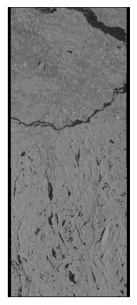

```python
#Here, we are taking a look at the MLI image to ensure that the multi-looking and mosaicing went well. If you see a satellite image, it means
#these steps were completed successfully. If done incorrectly, it is usually quite obvious as the image will be a random assortment of pixels.

im = plt.imread('20180916.slc.mli.bmp')
# Convert the image to grayscale
plt.imshow(im, cmap='gray')  # Display the grayscale image using 'gray' colormap
plt.axis('off')  # Turn off axis
plt.show()
```

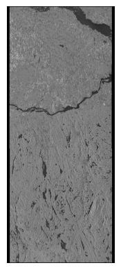

```python
im = plt.imread('20180928.slc.mli.bmp')
# Convert the image to grayscale
plt.imshow(im, cmap='gray')  # Display the grayscale image using 'gray' colormap
plt.axis('off')  # Turn off axis
plt.show()
```

```python
#Convert SRTM tiff to GAMMA format (.DEM)
pg.srtm2dem("E:/AlfredInSAR3/DEM/AlfredDEMMosaic2.tif", 'SRTM.dem', 'SRTM.dem_par', 0, '-')
```

```python
#pg.dem_import("E:/AlfredInSAR/DEM/output_COP30.tif", "COP.dem", "COP.dem_par", 0,"-" ) #if using a DEM that is not SRTM, use this function instead.
```

```python
#Calculate geocoding lookup table
pg.gc_map2('20180916.slc.mli.par', 'SRTM.dem_par', 'SRTM.dem', 'EQA.dem_par', 'EQA.dem', '20180916.lt', '3', '3', '20180916.ls_map', '-', '20180916.inc')
```

```
cmd: C:\GAMMA_SOFTWARE-20240111\DIFF\bin\gc_map2 20180916.slc.mli.par SRTM.dem_par SRTM.dem EQA.dem_par EQA.dem 20180916.lt 3 3 20180916.ls_map - 20180916.inc

*** Calculate lookup table and DEM related products (layover and shadow, incidence angle, local resolution, offnadir angle) ***
*** Generate accurate layover and shadow map for any platform heading ***
*** Copyright 2023, Gamma Remote Sensing, v5.7 28-Jul-2023 cm/cw/uw/of ***
OPENMP: number of physical processors:                     32
OPENMP: default max. number of threads (program specific): 8
OPENMP: current max. number of available threads:          32
OPENMP: number of program threads: 8

input image (MLI or SLC) parameter file: 20180916.slc.mli.par
DEM parameter file: SRTM.dem_par
DEM file: SRTM.dem
DEM segment parameter file: EQA.dem_par
DEM segment file: EQA.dem
geocoding lookup table file: 20180916.lt
layover-shadow ls_map file in original DEM coordinates: 20180916.ls_map
NOTE: no output file for layover/shadow map in range-azimuth coordinates
local incidence angle map file in original DEM coordinates: 20180916.inc
number of range samples:                 2574
number of azimuth lines:                 6122
azimuth angle: 90.0000 (right looking)  lr: 1

DEM REAL*4 data file: lines, width: 10801 14401
DEM data read: lines, width: 6049 6228

Calculating DEM segment...
done

starting DEM line:     54   column:     40
ending DEM line:     6036   column:   5819

Resampling DEM... done

Output size in DEM geometry: lines, width: 17947 17338

Calculating maps:
  line      0 of 17947
  line   1024 of 17947
  line   2048 of 17947
```

[output cut: 32 more lines]

```
  azimuth line   5632 of 6122
  azimuth line   6122 of 6122

Calculating layover and shadow...
 done

Converting coordinates of layover and shadow map into original DEM coordinates...
 done

Writing output files...
 done

DEM segment: width = 17338, nlines = 17947

real elapsed time (s):    114.897
```

```
0
```

```python
pg.pixel_area('20180916.slc.mli.par', 'EQA.dem_par', 'EQA.dem', '20180916.lt', '20180916.ls_map', '20180916.inc', '20180916.pix_sigma0', '20180916.pix_gamma0', 20)
```

```
cmd: C:\GAMMA_SOFTWARE-20240111\DIFF\bin\pixel_area 20180916.slc.mli.par EQA.dem_par EQA.dem 20180916.lt 20180916.ls_map 20180916.inc 20180916.pix_sigma0 20180916.pix_gamma0 20

*** Calculate terrain-based sigma0 and gammma0 normalization area in slant-range geometry ***
*** Copyright 2024, Gamma Remote Sensing, v3.2 8-Jan-2024 of/clw/uw/cm ***
OPENMP: number of physical processors:                     32
OPENMP: default max. number of threads (program specific): 3
OPENMP: current max. number of available threads:          32
OPENMP: number of program threads: 3

ISP image parameter file: 20180916.slc.mli.par
DEM parameter file: EQA.dem_par
geocoding lookup table: 20180916.lt
layover-shadow map file: 20180916.ls_map
local incidence angle map file: 20180916.inc
output sigma0 normalization area file: 20180916.pix_sigma0
output gamma0 normalization area file: 20180916.pix_gamma0

SLC slant range pixel spacing (m):  23.295620
SLC azimuth pixel spacing (m):      27.818680
number of range samples:                 2574
number of azimuth lines:                 6122
number of range looks:                     10
number of azimuth looks:                    2
DEM width:                              17338
DEM lines:                              17947
number of steps to divide each dimension of the map pixels: 20

memory allocation for 2D data buffers:    360.673 MB

numSteps: 20   elements/triangle: 200  pixfrac: 0.0050
area_factor: 1.000
range-azimuth pixel area (rps*azps): 648.05 [m^2]
threshold area (area_fact*rps*azps): 648.05 [m^2]

line:      0
line:   1000
line:   2000
line:   3000
line:   4000
line:   5000
line:   6000
line:   7000
line:   8000
line:   9000
line:  10000
line:  11000
line:  12000
line:  13000
line:  14000
line:  15000
line:  16000
line:  17000

range pixels: 2574   azimuth lines: 6122
sigma0 pixel area normalization data: 20180916.pix_sigma0
gamma0 pixel area normalization data: 20180916.pix_gamma0

real elapsed time (s):    123.474
```

```
0
```

```python
###### Convert to .bmp for easy visualization
pg.raspwr('20180916.pix_gamma0', 2574, '-', '-', '-', '-', '-', '-', '-', '20180916.pix_gamma0.bmp')
```

```
cmd: C:\GAMMA_SOFTWARE-20240111\DISP\bin\raspwr 20180916.pix_gamma0 2574 - - - - - - - 20180916.pix_gamma0.bmp

*** DISP Program C:\GAMMA_SOFTWARE-20240111\DISP\bin\raspwr ***
*** Copyright 2023, Gamma Remote Sensing, v1.7 19-Apr-2023 clw/cm ***
*** Calculate a raster image from data (FLOAT or UNSIGNED SHORT) with power-law scaling using a specified colormap ***
OPENMP: number of physical processors:                     32
OPENMP: default max. number of threads (program specific): 6
OPENMP: current max. number of available threads:          32
OPENMP: number of program threads: 6

input data filename: 20180916.pix_gamma0
data type: FLOAT
power-law display scale: 1.0000  exponent: 0.3500
DISP_HOME: C:\GAMMA_SOFTWARE-20240111\DISP
default colormap: gray.cm
default colormap path: C:\GAMMA_SOFTWARE-20240111\DISP/cmaps/gray.cm
number of colormap entries: 256
input data image width: 2574   height: 6122
starting line offset: 0
pixavx: 1   pixavy: 1
average intensity:   8.01875e+02  dB: 29.0411
power-law rel. scale: 1.000  exponent:0.3500  scale_factor:  4.8143e-02
line: 0
line: 2000
line: 4000
line: 6000

output image: 20180916.pix_gamma0.bmp
lines: 6122  width: 2574

real elapsed time (s):      1.504
```

```
0
```

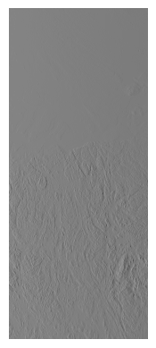

```python
#Here we are looking at our simulated backscatter image created using the DEM. After refinement, this will allow us to remove the tropospheric
#effects on the InSAR phase. You should see an image that looks like a hillshade.

im = plt.imread('20180916.pix_gamma0.bmp')
# Convert the image to grayscale
plt.imshow(im, cmap='gray')  # Display the grayscale image using 'gray' colormap
plt.axis('off')  # Turn off axis
plt.show()
```

```python
# determine geocoding refinement using offset_pwrm
pg.create_diff_par('20180916.slc.mli.par', '-', '20180916.diff_par', 1, 0)
pg.offset_pwrm('20180916.pix_gamma0', '20180916.slc.mli', '20180916.diff_par', '20180916.offs', '20180916.ccp', 128, 128, '20180916.offsets', 1, 64, 32, 0.1)
pg.offset_fitm('20180916.offs', '20180916.ccp', '20180916.diff_par', '20180916.coffs', '20180916.coffsets', 0.15, 1)
```

```
cmd: C:\GAMMA_SOFTWARE-20240111\DIFF\bin\create_diff_par 20180916.slc.mli.par - 20180916.diff_par 1 0

*** Create DIFF/GEO parameter file for geocoding and differential interferometry ***
*** Copyright 2023, Gamma Remote Sensing, v3.6 24-Apr-2023 clw/uw/cm ***
reading existing DIFF_par file: 20180916.diff_par:
PAR_type 1: (ISP image parameter files)
ISP SLC/MLI parameter file 1: 20180916.slc.mli.par
NOTE: no second ISP image parameter file provided

output DIFF/GEO parameter file: 20180916.diff_par
number of offsets range: 64  azimuth: 32
patch size range: 128  azimuth: 128
cross-correlation threshold: 0.100

real elapsed time (s):      0.006


cmd: C:\GAMMA_SOFTWARE-20240111\DIFF\bin\offset_pwrm 20180916.pix_gamma0 20180916.slc.mli 20180916.diff_par 20180916.offs 20180916.ccp 128 128 20180916.offsets 1 64 32 0.1

*** Offset estimation between MLI images using intensity cross-correlation ***
*** Copyright 2023, Gamma Remote Sensing, v5.7 20-Apr-2023 clw/cm ***
OPENMP: number of physical processors:                     32
OPENMP: default max. number of threads (program specific): 6
OPENMP: current max. number of available threads:          32
OPENMP: number of program threads: 6

C:\GAMMA_SOFTWARE-20240111\DIFF\bin\offset_pwrm compiled with GCC version: 13.1.0
offset estimates data file: 20180916.offs
cross-correlation (ccp) data file: 20180916.ccp

MLI1 image: 20180916.pix_gamma0
MLI2 image: 20180916.slc.mli
DIFF/GEO image parameter file: 20180916.diff_par
default cross-correlation coherence threshold for acceptance of offsets: 0.100
cross-correlation offset measurements: 20180916.offs
cross-correlation peak data file: 20180916.ccp
output offsets file (text format): 20180916.offsets
MLI oversampling factor: 1
number of range offset locations: 64
number of azimuth offset locations: 32
```

[output cut: 193 more lines]

```

total number of culling iterations: 4
final solution: 1155 offset estimates accepted out of 2048 samples

final range offset poly. coeff.:                1.19165
final azimuth offset poly. coeff.:             -0.29861

final range offset poly. coeff. errors:     5.04384e-03
final azimuth offset poly. coeff. errors:   6.41136e-03
final model fit std. dev. (samples) range: 0.0964   azimuth: 0.1225

binary culled offsets: 20180916.coffs
updating DIFF/GEO parameters: 20180916.diff_par

real elapsed time (s):      0.002
```

```
0
```

```python
# refine geocoding lookup table
pg.gc_map_fine('20180916.lt', 17338, '20180916.diff_par', '20180916.lt_fine', 1)
```

```
cmd: C:\GAMMA_SOFTWARE-20240111\DIFF\bin\gc_map_fine 20180916.lt 17338 20180916.diff_par 20180916.lt_fine 1

*** Geocoding lookup table refinement using DIFF_par offset polynomials ***
*** Copyright 2011, Gamma Remote Sensing, v2.1 8-Apr-2011 clw/uw ***

NOTE: simulated SAR image is reference
input lookup table width:   17338

range offset polynomial:   a0 + a1*r + a2*az+ a3*r*az + a4*r*r + a5*az*az
range offset polynomial coeff.:        1.1917    0.0000e+00    0.0000e+00    0.0000e+00    0.0000e+00    0.0000e+00

azimuth offset polynomial: b0 + b1*r + b2*az+ b3*r*az + b4*r*r + b5*az*az
azimuth offset polynomial coeff.:     -0.2986    0.0000e+00    0.0000e+00    0.0000e+00    0.0000e+00    0.0000e+00

input lookup table width: 17338  lines: 17947


processing line:      0

processing line:   1000

processing line:   2000

processing line:   3000

processing line:   4000

processing line:   5000

processing line:   6000

processing line:   7000

processing line:   8000

processing line:   9000

processing line:  10000

processing line:  11000

processing line:  12000

processing line:  13000

processing line:  14000

processing line:  15000

processing line:  16000

processing line:  17000

real elapsed time (s):      1.673
```

```
0
```

```python
pg.pixel_area('20180916.slc.mli.par', 'EQA.dem_par', 'EQA.dem', '20180916.lt_fine', '20180916.ls_map', '20180916.inc', '20180916.pix_sigma0_fine', '20180916.pix_gamma0_fine')
```

```
cmd: C:\GAMMA_SOFTWARE-20240111\DIFF\bin\pixel_area 20180916.slc.mli.par EQA.dem_par EQA.dem 20180916.lt_fine 20180916.ls_map 20180916.inc 20180916.pix_sigma0_fine 20180916.pix_gamma0_fine

*** Calculate terrain-based sigma0 and gammma0 normalization area in slant-range geometry ***
*** Copyright 2024, Gamma Remote Sensing, v3.2 8-Jan-2024 of/clw/uw/cm ***
OPENMP: number of physical processors:                     32
OPENMP: default max. number of threads (program specific): 3
OPENMP: current max. number of available threads:          32
OPENMP: number of program threads: 3

ISP image parameter file: 20180916.slc.mli.par
DEM parameter file: EQA.dem_par
geocoding lookup table: 20180916.lt_fine
layover-shadow map file: 20180916.ls_map
local incidence angle map file: 20180916.inc
output sigma0 normalization area file: 20180916.pix_sigma0_fine
output gamma0 normalization area file: 20180916.pix_gamma0_fine

SLC slant range pixel spacing (m):  23.295620
SLC azimuth pixel spacing (m):      27.818680
number of range samples:                 2574
number of azimuth lines:                 6122
number of range looks:                     10
number of azimuth looks:                    2
DEM width:                              17338
DEM lines:                              17947
number of steps to divide each dimension of the map pixels: 16

memory allocation for 2D data buffers:    360.673 MB

numSteps: 16   elements/triangle: 128  pixfrac: 0.0078
area_factor: 1.000
range-azimuth pixel area (rps*azps): 648.05 [m^2]
threshold area (area_fact*rps*azps): 648.05 [m^2]

line:      0
line:   1000
line:   2000
line:   3000
line:   4000
line:   5000
line:   6000
line:   7000
line:   8000
line:   9000
line:  10000
line:  11000
line:  12000
line:  13000
line:  14000
line:  15000
line:  16000
line:  17000

range pixels: 2574   azimuth lines: 6122
sigma0 pixel area normalization data: 20180916.pix_sigma0_fine
gamma0 pixel area normalization data: 20180916.pix_gamma0_fine

real elapsed time (s):     87.736
```

```
0
```

```python
pg.raspwr('20180916.pix_gamma0_fine', 2574, '-', '-', '-', '-', '-', '-', '-', '20180916.pix_gamma0_fine.bmp')
```

```
cmd: C:\GAMMA_SOFTWARE-20240111\DISP\bin\raspwr 20180916.pix_gamma0_fine 2574 - - - - - - - 20180916.pix_gamma0_fine.bmp

*** DISP Program C:\GAMMA_SOFTWARE-20240111\DISP\bin\raspwr ***
*** Copyright 2023, Gamma Remote Sensing, v1.7 19-Apr-2023 clw/cm ***
*** Calculate a raster image from data (FLOAT or UNSIGNED SHORT) with power-law scaling using a specified colormap ***
OPENMP: number of physical processors:                     32
OPENMP: default max. number of threads (program specific): 6
OPENMP: current max. number of available threads:          32
OPENMP: number of program threads: 6

input data filename: 20180916.pix_gamma0_fine
data type: FLOAT
power-law display scale: 1.0000  exponent: 0.3500
DISP_HOME: C:\GAMMA_SOFTWARE-20240111\DISP
default colormap: gray.cm
default colormap path: C:\GAMMA_SOFTWARE-20240111\DISP/cmaps/gray.cm
number of colormap entries: 256
input data image width: 2574   height: 6122
starting line offset: 0
pixavx: 1   pixavy: 1
average intensity:   8.02424e+02  dB: 29.0440
power-law rel. scale: 1.000  exponent:0.3500  scale_factor:  4.8131e-02
line: 0
line: 2000
line: 4000
line: 6000

output image: 20180916.pix_gamma0_fine.bmp
lines: 6122  width: 2574

real elapsed time (s):      1.507
```

```
0
```

```python
pg.geocode_back('20180916.slc.mli', 2574, '20180916.lt_fine', 'EQA.20180916.slc.mli', 17338, 0, 5, 0, '-', '-', 3)
```

```
cmd: C:\GAMMA_SOFTWARE-20240111\DIFF\bin\geocode_back 20180916.slc.mli 2574 20180916.lt_fine EQA.20180916.slc.mli 17338 0 5 0 - - 3

*** Geocoding of image data using a geocoding lookup table ***
*** Copyright 2023, Gamma Remote Sensing, v5.0 12-Sep-2023 clw/uw/of/cm ***
OPENMP: number of physical processors:                     32
OPENMP: default max. number of threads (program specific): 8
OPENMP: current max. number of available threads:          32
OPENMP: number of program threads: 8

input data file:  20180916.slc.mli
lookup table:     20180916.lt_fine
output data file: EQA.20180916.slc.mli

lookup table width: 17338   lines: 17947
interpolation mode: 5
B-spline interpolation, degree: 3, sqrt(data)
input/output data format: FLOAT

input data width, nlines:       2574    6122
output data width, nlines:     17338   17947


output data line:      0

output data line:   2000

output data line:   4000

output data line:   6000

output data line:   8000

output data line:  10000

output data line:  12000

output data line:  14000

output data line:  16000

output file: EQA.20180916.slc.mli
output file width: 17338  lines: 17947

real elapsed time (s):      9.196
```

```
0
```

```python
pg.geocode('20180916.lt_fine', 'EQA.dem', 18337, '20180916.hgt', 2574, 6122, 2, 0) #Sometimes the DEM and the SAR image won't have the same number of lines. Just set how many lines you need here ex. 6116.
```

```
cmd: C:\GAMMA_SOFTWARE-20240111\DIFF\bin\geocode 20180916.lt_fine EQA.dem 18337 20180916.hgt 2574 6122 2 0

*** Forward geocoding transformation using a lookup table ***
*** Copyright 2019, Gamma Remote Sensing, v4.3 12-Mar-2019 uw/clw/of/cm ***
data format: float
interpolation: convolution with (1/r)**2 weighting
interpolation oversampling factor: 2
interpolation search radius: 8
number of points used for interpolation: 4
number of entries in the interpolation search table: 208

input data width, nlines:    18337   16969
output data width, nlines:    2574    6122
interpolation arrays width: 5162  lines: 26001
number of output lines/block: 12993
number of output blocks: 1
output block:  1   starting line:      0

output data file: 20180916.hgt
output file width: 2574   lines: 6122

real elapsed time (s):      3.153
```

```
0
```

```python
pg.rasdt_pwr('20180916.hgt', '20180916.slc.mli', 2574, '-', '-', '-', '-', 0, 500, 1, 'rmg.cm', '20180916.hgt.bmp')
```

```
cmd: C:\GAMMA_SOFTWARE-20240111\DISP\bin\rasdt_pwr 20180916.hgt 20180916.slc.mli 2574 - - - - 0 500 1 rmg.cm 20180916.hgt.bmp

*** DISP Program C:\GAMMA_SOFTWARE-20240111\DISP\bin\rasdt_pwr ***
*** Copyright 2023, Gamma Remote Sensing, v2.4 19-Apr-2023 clw/cm ***
*** Calculate a raster image of data (FLOAT) with linear scaling using a specified colormap combined with power-law scaled intensity (8 or 24-bits/pixel) ***
OPENMP: number of physical processors:                     32
OPENMP: default max. number of threads (program specific): 6
OPENMP: current max. number of available threads:          32
OPENMP: number of program threads: 6

data file: 20180916.hgt
intensity image background: 20180916.slc.mli
input data filename: 20180916.hgt
output raster image filename: 20180916.hgt.bmp
bits/output pixel: 8
DISP_HOME: C:\GAMMA_SOFTWARE-20240111\DISP
colormap: rmg.cm
searching in colormap directory C:\GAMMA_SOFTWARE-20240111\DISP/cmaps/
number of colormap entries: 256
input data filename:   20180916.hgt
input data image width:   2574   height: 6122
input intensity image filename: 20180916.slc.mli
input intensity image width: 2574   height: 6122
cyclic data display min:  0.0000e+00   max:  5.0000e+02   cycle:  5.0000e+02
output raster image: 20180916.hgt.bmp
number of lines to process: 6122
range looks: 1   azimuth looks: 1
output image width: 2574   height: 6122
average intensity: 1.14680e-01  dB:  -9.4051
power-law scale factor:  1.000  exponent: 0.3500  scale factor: 1.28035e+00
line: 0
line: 2000
line: 4000
line: 6000

output image: 20180916.hgt.bmp    bits/pixel: 8
raster image lines: 6122  width: 2574

real elapsed time (s):      0.645
```

```
0
```

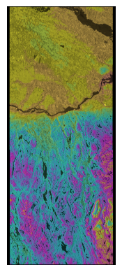

```python
#Here we are looking at our height map overlaid with a MLI image.

#Visualize the height map
im = plt.imread('20180916.hgt.bmp')
# Convert the image to grayscale
plt.imshow(im, cmap='gray')  # Display the grayscale image using 'gray' colormap
plt.axis('off')  # Turn off axis
plt.show()
```

# Coregistration

Now it is time to coregister our two images. Very simply, we want to precisely align them at the sub-pixel level, which is necessscary for InSAR. The following steps will walk you through manual coregistration. Alternatively, there is a script created by GAMMA called ScanSAR_coreg.py to handle the majority of the coregistration procedure. As an input, it requires two SLCs and the height map we created during the earlier geocoding process.

Here, we will be applying mor than one method applied teratively improve the co-registration refinement. First, a matching procedure using offset_pwr and then a spectral diversity method (script S1_coreg_overlap) which considers the interferometric phase of the burst overlap region. Note that the same group of functions is reepeated several times. If necesscary, these can be repeated as many times as necesscary to achieve the required coregistration threshold.

```python
pg.rdc_trans('20210504.slc.mli.par', '20210504.hgt', '20210516.slc.mli.par', '20210516.slc.mli.lt')
```

```python
pg.geocode('20210516.slc.mli.lt', '20210504.slc.mli', 2241, '20210516.slc.sim', 2241, 6116, 0, 0)
```

```python
pg.create_diff_par('20210516.slc.mli.par', '-', '20210516.slc.diff_par', 1, 0)
```

```python
pg.offset_pwrm('20210516.slc.sim', '20210516.slc.mli', '20210516.slc.diff_par', '20210516.slc.offs', '20210516.slc.ccp', 128, 128, '20210516.slc.offsets', 1, 64, 32, 0.1)
```

```python
pg.offset_fitm('20210516.slc.offs', '20210516.slc.ccp', '20210516.slc.diff_par', '20210516.slc.coffs', '20210516.slc.coffsets', 0.15, 1)
```

```python
pg.gc_map_fine('20210516.slc.mli.lt', 2241, '20210516.slc.diff_par', '20210516.slc.mli.lt_fine', 1)
```

```python
pg.geocode('20210516.slc.mli.lt_fine', '20210516.slc.mli', 2241, '20210516.slc.sim', 2241, 6116, 0, 0)
```

```python
pg.create_diff_par('20210516.slc.mli.par', '-', '20210516.slc.diff_par.iteration1', 1, 0)
```

```python
pg.offset_pwrm('20210516.slc.sim', '20210516.slc.mli', '20210516.slc.diff_par.iteration1', '20210516.slc.offs', '20210516.slc.ccp', 128, 128, '20210516.slc.offsets', 1, 64, 32, 0.1)
```

```python
pg.offset_fitm('20210516.slc.offs', '20210516.slc.ccp', '20210516.slc.diff_par.iteration1', '20210516.slc.coffs', '20210516.slc.coffsets', 0.15, 1)
```

Slightly easier to run this in the command line rather than copying the file with python. Use MSYS MINGW 64 for this part

/bin/cp 20210516.slc.mli.lt_fine 20210516.slc.mli.lt0

```python
pg.gc_map_fine('20210516.slc.mli.lt0', 2241, '20210516.slc.diff_par.iteration1', '20210516.slc.mli.lt_fine', 1)
```

```python
pg.create_offset('20210504.slc.par', '20210516.slc.par', '20210504_20210516.off', 1, 10, 2, 0)
```

```python
prefix = "IW1.20210516" #Change the prefix each time you run this, should be once for each image you're using.

column1 = prefix  + ".slc"
column2 = prefix + ".slc.par"
column3 = prefix + ".slc.TOPS_par"

# Open a file in write mode
with open(Outputdir + "\\" "SLC2_tab", "w") as f:
    # Write the strings for each column separated by tabs
    f.write(f"{column1}\t{column2}\t{column3}\n")


print("Wrote to " + Outputdir + "\\" + prefix + ".SLC_tab")
```

```python
prefix = "IW1.20210504" #Change the prefix each time you run this, should be once for each image you're using.

column1 = prefix  + ".rslc"
column2 = prefix + ".rslc.par"
column3 = prefix + ".rslc.TOPS_par"

# Open a file in write mode
with open(Outputdir + "\\" + prefix + ".RSLC1_tab", "w") as f:
    # Write the strings for each column separated by tabs
    f.write(f"{column1}\t{column2}\t{column3}\n")


print("Wrote to " + Outputdir + "\\" + prefix + ".SLC_tab")
```

```python
pg.SLC_interp_lt_ScanSAR('IW1.20210516.SLC_tab', '20210516.slc.par', 'IW1.20210504.SLC_tab 20210504.slc.par', '20210516.slc.mli.lt_fine', '20210504.slc.mli.par', '20210516.slc.mli.par', '-', 'RSLC2_tab 20210516.rslc 20210516.rslc.par')
```

```python
pg.create_offset('20210504.slc.par', '20210516.slc.par', '20210504_20210516.off', 1, 10, 2, 0)
```

```python
pg.offset_pwr('20210504.slc', '20210516.rslc', '20210504.slc.par', '20210516.rslc.par', '20210504_20210516.off', '20210504_20210516.offs', \
              '20210504_20210516.ccp', 512, 128, '-', 1, 64, 32, 0.1)
```

```python
pg.offset_fit('20210504_20210516.offs', '20210504_20210516.ccp', '20210504_20210516.off', '-', '-', 0.15, 1, 0)
```

```python
pg.SLC_interp_lt_ScanSAR('SLC2_tab', '20210516.slc.par', 'SLC1_tab', '20210504.slc.par', '20210516.slc.mli.lt_fine', '20210504.slc.mli.par', \
                         '20210516.slc.mli.par', '20210504_20210516.off', 'RSLC2_tab', '20210516.rslc', '20210516.rslc.par')
```

```python
pg.create_offset('20210504.slc.par', '20210516.slc.par', '20210504_20210516.off1', 1, 10, 2, 0)
```

```python
pg.offset_pwr('20210504.slc', '20210516.rslc', '20210504.slc.par', '20210516.rslc.par', '20210504_20210516.off1',\
              '20210504_20210516.offs',' 20210504_20210516.ccp', 512, 128, '-', 1, 64, 32, 0.1)
```

```python
pg.offset_fit('20210504_20210516.offs', '20210504_20210516.ccp', '20210504_20210516.off1', 'coffs', 'coffsets', 0.3, 1, 0)
```

Again, another command which is more simply executed through a linux-esque terminal

/bin/cp 20210504_20210516.off 20210504_20210516.off0

```python
pg.offset_add('20210504_20210516.off0', '20210504_20210516.off1', '20210504_20210516.off')
```

```python
pg.SLC_interp_lt_ScanSAR('SLC2_tab', '20210516.slc.par', 'SLC1_tab', '20210504.slc.par', '20210516.slc.mli.lt_fine', \
'20210504.slc.mli.par', '20210516.slc.mli.par', '20210504_20210516.off', 'RSLC2_tab', '20210516.rslc', '20210516.rslc.par')
```

```python
pg.phase_sim_orb('20210504.slc.par', '20210516.slc.par', '20210504_20210516.off', '20210504.hgt', '20210504_20210516.sim_unw', '20210504.slc.par',  '-', '-', 1, 1)
```

```python
pg.SLC_diff_intf('20210504.slc', '20210516.rslc', '20210504.slc.par', '20210516.rslc.par', \
                 '20210504_20210516.off', '20210504_20210516.sim_unw', '20210504_20210516.diff', 10, 2, 0, 0, 0.2, 1, 1)
```

```python
pg.rasmph_pwr('20210504_20210516.diff', '20210504.slc.mli', 2241, '-', '-', '-', '-', '-', '20210504_20210516.diff.test1.bmp', '-', '-', 24)
```

eog 20210504_20210516.diff.test1.bmp &

Here we will use the spectral diversity method to determine small azimuth offset refinement correction using the phase jump in the burst overlap regions

We will apply a script for spectral diversity method (S1_coreg_overlap) which calculates the burst overlap region and an interferogram. I then calculates the phase difference bewtween the two, upwraps it, and determines a spatial average of the phase over the high coherence ares. This is done for each overlap region. The resulting phase differences are averaged and converted to an azimuth offset refinement correction

```python
%run ScanSAR_coreg_overlap.py SLC1_tab RSLC2_tab 20210504_20210616 20210504_20210516.off 20210504_20210516.off.corrected
```

```python
pg.SLC_interp_lt_ScanSAR('SLC2_tab', '20210516.slc.par', 'SLC1_tab', '20210504.slc.par', '20210516.slc.mli.lt_fine', '20210504.slc.mli.par', \
'20210516.slc.mli.par', '20210504_20210516.off.corrected', 'RSLC2_tab', '20141015.rslc', '20141015.rslc.par')
```

```python
pg.SLC_diff_intf('20210504.slc', '20210516.rslc', '20210504.slc.par', '20210516.rslc.par', '20210504_20210516.off', \
                 '20210504_20210516.sim_unw', '20210504_20210516.diff', 10, 2, 0, 0, 0.2, 1, 1)

pg.rasmph_pwr('20210504_20210516.diff', '20210504.slc.mli', 2241, '-', '-', '-', '-', '-', '20210504_20210516.diff.test2.bmp', '-', '-', 24)
```

All of the above code is contained within the shell script "ScanSAR_coreg.py". This is a time saver, but it is nice to understand what each of the functions are doing on their own.

```python
%run -i ScanSAR_coreg.py IW1.20180916.SLC_tab 20180916_Out IW1.20180928.SLC_tab 20180928_Out 20180916_20180928.RSLC2_tab 20180916.hgt - - 10 2
```

```
*** ScanSAR_coreg.py: Script to coregister a ScanSAR or TOPS mode burst SLC to a reference burst SLC ***
*** Copyright 2023 Gamma Remote Sensing, v3.9 20-Jul-2023 cm/uw ***

ScanSAR_coreg.py arguments: ['IW1.20180916.SLC_tab', '20180916_Out', 'IW1.20180928.SLC_tab', '20180928_Out', '20180916_20180928.RSLC2_tab', '20180916.hgt', '-', '-', '10', '2']
ScanSAR_coreg.py options: []

using the height file 20180916.hgt
cmd: csh C:\GAMMA_SOFTWARE-20240111\ISP\scripts\get_GAMMA_RASTER 0

raster image file extension from get_GAMMA_RASTER: bmp
LAT program poly_mask is available

Successfully created the directory ./tmp_dir_coreg_232543846019

cmd: python C:\GAMMA_SOFTWARE-20240111\DIFF\scripts\ScanSAR_coreg_check.py IW1.20180916.SLC_tab IW1.20180928.SLC_tab ./tmp_dir_coreg_232543846019/IW1.20180928.SLC_tab_mod . 1

*** ScanSAR_coreg_check.py: Script to check and adapt a ScanSAR or TOPS burst SLC relative to a reference burst SLC ***
*** Copyright 2023 Gamma Remote Sensing, v2.2 2-Nov-2023 cm ***

SLC1_tab: IW1.20180916.SLC_tab
SLC2_tab: IW1.20180928.SLC_tab

Successfully created the directory ./tmp_dir_coreg_check_232545682107
cmd: C:\GAMMA_SOFTWARE-20240111\ISP\bin\SLC_mosaic_ScanSAR ./tmp_dir_coreg_check_232545682107/SLC_tab1 ./tmp_dir_coreg_check_232545682107/SLC1_mosaic.slc ./tmp_dir_coreg_check_232545682107/SLC1_mosaic.slc.par 1 1 1

cmd: C:\GAMMA_SOFTWARE-20240111\ISP\bin\SLC_mosaic_ScanSAR ./tmp_dir_coreg_check_232545682107/SLC_tab2 ./tmp_dir_coreg_check_232545682107/SLC2_mosaic.slc ./tmp_dir_coreg_check_232545682107/SLC2_mosaic.slc.par 1 1 1

cmd: C:\GAMMA_SOFTWARE-20240111\DIFF\bin\sarpix_coord_list ./tmp_dir_coreg_check_232545682107/SLC1_mosaic.slc.par - - ./tmp_dir_coreg_check_232545682107/SAR_coord_1 ./tmp_dir_coreg_check_232545682107/MAP_coord_1

cmd: C:\GAMMA_SOFTWARE-20240111\DIFF\bin\coord_to_sarpix_list ./tmp_dir_coreg_check_232545682107/SLC2_mosaic.slc.par - - ./tmp_dir_coreg_check_232545682107/MAP_coord_1 ./tmp_dir_coreg_check_232545682107/SAR_coord_2

#########################################################################
Results of ScanSAR_coreg_check.py:

The second scene subswaths and bursts correspond to the reference
#########################################################################

Successfully deleted the directory ./tmp_dir_coreg_check_232545682107

end of ScanSAR_coreg_check.py, elapsed time (s): 3.203762
```

[output cut: 1917 more lines]

```
line: 0
line: 2000
line: 4000
line: 6000

output image: ./20180916_Out_20180928_Out.diff.bmp    bits/pixel: 8
raster image lines: 6122  width: 2574

real elapsed time (s):      0.729



Successfully deleted the directory ./tmp_dir_coreg_232543846019

end of ScanSAR_coreg.py, elapsed time (s): 161.591788
```

# Calculation of S1 differential interferogram

Here, we will be calculating the differential interferogram.

First, we will do a topographic phase simulation (similar to what we did during geocoding), then calculate the differential interferogram.

```python
# calculation of a S1 TOPS differential interferogram

# topographic phase simulation
pg.phase_sim_orb('20180916.slc.par', '20180928.slc.par', '20180916_Out_20180928_Out.off', '20180916.hgt', '20180916_Out_20180928_Out.sim_unw', '20180916.slc.par', '-', '6', 1, 1)
```

```
cmd: C:\GAMMA_SOFTWARE-20240111\DIFF\bin\phase_sim_orb 20180916.slc.par 20180928.slc.par 20180916_Out_20180928_Out.off 20180916.hgt 20180916_Out_20180928_Out.sim_unw 20180916.slc.par - 6 1 1

*** Simulate unwrapped interferometric phase using DEM height and deformation rate using orbit state vectors ***
*** Copyright 2023, Gamma Remote Sensing, v3.2 13-Sep-2023 clw/cm ***
OPENMP: number of physical processors:                     32
OPENMP: default max. number of threads (program specific): 8
OPENMP: current max. number of available threads:          32
OPENMP: number of program threads: 8

SLC1 image parameter file:  20180916.slc.par
SLC2R image parameter file: 20180928.slc.par

ISP interferogram/offset parameter file: 20180916_Out_20180928_Out.off
height map file: 20180916.hgt
output simulated interferometric phase: 20180916_Out_20180928_Out.sim_unw
geometric reference SLC parameter file: 20180916.slc.par
NOTE: no deformation rate file entered: deformation rate set to 0.0
int_mode = 1: repeat-pass interferometric mode (default)

interferogram lines: 6122   range samples: 2574
SLC1 wavevector (rad/m):      -226.560868
SLC2 wavevector (rad/m):      -226.560868
interf. slant range pixel (m):  23.295620
interf. azimuth pixel (m):      27.818680
SLC slant range pixel (m):       2.329562
SLC azimuth pixel (m):          13.909340
effective PRF (Hz):               486.486
Doppler centroid (Hz):             27.514
SLC data are deskewed: zero Doppler is used for baseline estimation
SAR antenna azimuth angle (deg.):   90.00 (right looking)
NOTE: using geometric reference SLC parameters: 20180916.slc.par

ph_mode 1: subtracting a multiple of 2PI from the absolute phase -2k(R1 - R2)
simulated phase at image center (radians): -8825.8846
phase constant to subtract (radians): -8827.8754  multiples of 2PI: -1405

output line:      0  SLC1 azimuth line: 0.5
output line:   1000  SLC1 azimuth line: 2000.5
output line:   2000  SLC1 azimuth line: 4000.5
output line:   3000  SLC1 azimuth line: 6000.5
output line:   4000  SLC1 azimuth line: 8000.5
output line:   5000  SLC1 azimuth line: 10000.5
output line:   6000  SLC1 azimuth line: 12000.5

simulated unwrapped phase: 20180916_Out_20180928_Out.sim_unw
width: 2574 lines: 6122

real elapsed time (s):     29.809
```

```
0
```

```python
# calculate differential interferogram
pg.SLC_diff_intf('20180916.slc', '20180928_Out.rslc', '20180916.slc.par', '20180928_Out.rslc.par', '20180916_Out_20180928_Out.off', \
                 '20180916_Out_20180928_Out.sim_unw', '20180916_Out_20180928_Out.diff', 10, 2, 1, 1, 0.2)
```

```
cmd: C:\GAMMA_SOFTWARE-20240111\DIFF\bin\SLC_diff_intf 20180916.slc 20180928_Out.rslc 20180916.slc.par 20180928_Out.rslc.par 20180916_Out_20180928_Out.off 20180916_Out_20180928_Out.sim_unw 20180916_Out_20180928_Out.diff 10 2 1 1 0.2

*** Differential interferogram generation from co-registered SLCs and a simulated interferogram ***
*** Copyright 2023, Gamma Remote Sensing, v4.7 clw/uw/cm 21-Nov-2023 ***
OPENMP: number of physical processors:                     32
OPENMP: default max. number of threads (program specific): 6
OPENMP: current max. number of available threads:          32
OPENMP: number of program threads: 6

NOTE: applying common range spectrum filtering
NOTE: applying azimuth common band filter
SLC1 phase: zero-Doppler geometry
SLC2R phase: zero-Doppler geometry
lines in the simulated interferogram file: 6122
number of azimuth common band filter sections: 26
azimth FFT size: 2048  filter length: 65   points saved/segment: 1983

IMAGE/OFFSET PARAMETERS:
line offset relative to start of SLC1:           0
number of lines to process SLC1:             12244
SLC1 range samples:                          25745
SLC1 azimuth samples (along-track):          12245
SLC1 line header size (bytes)                    0
SLC1 range pixel size (m):                 2.32956
SLC1 azimuth pixel size (m):              13.90934

SLC2 range samples:                          25745
SLC2 azimuth samples (along-track):          12245
SLC2 line header size (bytes)                    0

range_offset_polynomial:      0.0000e+00   0.0000e+00   0.0000e+00   0.0000e+00
azimuth_offset_polynomial:   -4.0000e-05   0.0000e+00   0.0000e+00   0.0000e+00
number of lines in the simulated interferogram: 6122
resampled SLC2R width (samples):             25745
interferogram range looks:                      10
interferogram azimuth looks:                     2
interferogram range pixel spacing (m):    23.29562
interferogram azimuth pixel spacing (m):  27.81868
interferogram width (samples):                2574
number of azimuth common band filters: 26
```

[output cut: 1460 more lines]

[output not shown]

```
0
```

```python
pg.rasmph_pwr('20180916_Out_20180928_Out.diff', '20180916.slc.mli', 2574, '-', '-', '-', '-', '-', '20180916_Out_20180928_Out.diff.bmp', '-', '-', 24)
```

```
cmd: C:\GAMMA_SOFTWARE-20240111\DISP\bin\rasmph_pwr 20180916_Out_20180928_Out.diff 20180916.slc.mli 2574 - - - - - 20180916_Out_20180928_Out.diff.bmp - - 24

*** DISP Program C:\GAMMA_SOFTWARE-20240111\DISP\bin\rasmph_pwr ***
*** Copyright 2023, Gamma Remote Sensing, v2.0 19-Apr-2023 clw/cm ***
*** Calculate a raster image of FCOMPLEX data phase using a specified colormap combined with power-law scaled intensity (8 or 24-bits/pixel) ***
OPENMP: number of physical processors:                     32
OPENMP: default max. number of threads (program specific): 6
OPENMP: current max. number of available threads:          32
OPENMP: number of program threads: 6

data file: 20180916_Out_20180928_Out.diff
intensity image background: 20180916.slc.mli
output raster image filename: 20180916_Out_20180928_Out.diff.bmp
bits/display pixel: 24
DISP_HOME: C:\GAMMA_SOFTWARE-20240111\DISP
default colormap: rmg.cm
default colormap path: C:\GAMMA_SOFTWARE-20240111\DISP/cmaps/rmg.cm
number of colormap entries: 256
input data filename: 20180916_Out_20180928_Out.diff
input data image width:   2574   height: 6122
input intensity image filename: 20180916.slc.mli
input intensity image width: 2574   height: 6122
number of lines to process: 6122
range looks: 1   azimuth looks: 1
output image width: 2574   height: 6122
average intensity: 1.14680e-01  dB:  -9.4051
power-law scale factor:  1.000  exponent: 0.3500  scale factor: 1.28035e+00
line: 0
line: 2000
line: 4000
line: 6000

output image: 20180916_Out_20180928_Out.diff.bmp    bits/pixel: 24
raster image lines: 6122  width: 2574

real elapsed time (s):      0.813
```

```
0
```

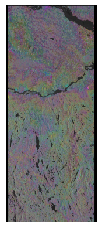

```python
im = plt.imread('20180916_Out_20180928_Out.diff.bmp')
# Convert the image to grayscale
plt.imshow(im, cmap='gray')  # Display the grayscale image using 'gray' colormap
plt.axis('off')  # Turn off axis
plt.show()
```

# Estimate coherence

In this section, we are going to create and export a coherence image, which is the phase correlation between are two images. Coherence is useful data on its own, as it is an indicator of image quality, and can be used to mask problem pixels during the phase unwrapping process.

```python
pg.multi_look('20180916.slc', '20180916.slc.par', '20180916.slc.mli', '20180916.slc.mli.par', 10, 2, 0, '-', 0.000001)
pg.multi_look('20180928_Out.rslc', '20180928_Out.rslc.par', '20180928_Out.rmli', '20180928_Out.rmli.par', 10, 2, 0, '-', 0.000001)
```

```
cmd: C:\GAMMA_SOFTWARE-20240111\ISP\bin\multi_look 20180916.slc 20180916.slc.par 20180916.slc.mli 20180916.slc.mli.par 10 2 0 - 1e-06

*** Calculate a multi-look intensity (MLI) image from an SLC image ***
*** Copyright 2022, Gamma Remote Sensing, v4.7 8-Aug-2022 clw/uw/cm ***
OPENMP: number of physical processors:                     32
OPENMP: default max. number of threads (program specific): 6
OPENMP: current max. number of available threads:          32
OPENMP: number of program threads: 6

SLC file: 20180916.slc
SLC parameter file: 20180916.slc.par
MLI file: 20180916.slc.mli
MLI parameter file: 20180916.slc.mli.par
radar sensor: S1A IW IW2 VV

NOTE: retaining incidence angle at image center for entire SLC image frame
NOTE: retaining doppler parameters for entire SLC image frame

SLC format: scomplex (pairs of 2-byte integer (re,im))
range looks:                  10
azimuth looks:                 2
offset to starting line:       0
number of lines:           12245
relative output scale factor: 0.000001
output exponent: 1.000000

SLC title:                      s1a-iw2-slc-vv-20180916t225221-20180916t225247-023730-02965b-005.tiff S1A-IW-IW2-VV-23730 (software: Sentinel-1 IPF 002.91)
input line header size (bytes):          0
SLC range sample spacing (m):      2.32956
SLC azimuth sample spacing (m):   13.90934
SLC image range samples:             25745
SLC image azimuth lines:             12245

MLI range sample spacing (m):     23.29562
MLI azimuth sample spacing (m):   27.81868
MLI image range samples:              2574
MLI image azimuth lines:              6122

multi-look output line:      0
multi-look output line:   2000
```

[output cut: 41 more lines]

```

MLI range sample spacing (m):     23.29354
MLI azimuth sample spacing (m):   27.81864
MLI image range samples:              2574
MLI image azimuth lines:              6122

multi-look output line:      0
multi-look output line:   2000
multi-look output line:   4000
multi-look output line:   6000

output MLI file: 20180928_Out.rmli
width: 2574  lines: 6122

real elapsed time (s):      1.265
```

```
0
```

```python
pg.cc_ad('20180916_Out_20180928_Out.diff', '20180916.slc.mli', '20180928_Out.rmli', '-', '-', '20180916_Out_20180928_Out.diff.cc', 2574, 3., 9., 0)
```

```
cmd: C:\GAMMA_SOFTWARE-20240111\LAT\bin\cc_ad 20180916_Out_20180928_Out.diff 20180916.slc.mli 20180928_Out.rmli - - 20180916_Out_20180928_Out.diff.cc 2574 3.0 9.0 0

*** LAT cc_ad: Adaptive coherence estimation with consideration of phase slope and texture ***
*** Copyright 2023, Gamma Remote Sensing, v4.3 1-Dec-2023 clw/uw/cm ***
OPENMP maximum available threads : 32
OPENMP: setting number of theads: 8
coherence estimation not considering local terrain slope
coherence estimation not adaptive to backscatter texture

input interferogram width: 2574  lines: 6122
offset to starting line: 0
number of lines to process: 6122

wgt_flag: 0
box_min, dx_min_int, box_min_int:   3.00     1     3
box_max, dx_max_int, box_max_int:   9.00     4     9

adaptive estimation window size as a function of initial coherence estimate
coherence:    0.00  0.10  0.20  0.30  0.40  0.50  0.60  0.70  0.80  0.90  1.00
boxsize:      9.00  8.40  7.80  7.20  6.60  6.00  5.40  4.80  4.20  3.60  3.00

weights for box_min:
 0.000 0.000 0.000 0.000 0.000 0.000 0.000 0.000 0.000
 0.000 0.000 0.000 0.000 0.000 0.000 0.000 0.000 0.000
 0.000 0.000 0.000 0.000 0.000 0.000 0.000 0.000 0.000
 0.000 0.000 0.000 0.343 1.000 0.343 0.000 0.000 0.000
 0.000 0.000 0.000 1.000 1.000 1.000 0.000 0.000 0.000
 0.000 0.000 0.000 0.343 1.000 0.343 0.000 0.000 0.000
 0.000 0.000 0.000 0.000 0.000 0.000 0.000 0.000 0.000
 0.000 0.000 0.000 0.000 0.000 0.000 0.000 0.000 0.000
 0.000 0.000 0.000 0.000 0.000 0.000 0.000 0.000 0.000

weights for box_max:
 0.000 0.000 0.279 0.769 1.000 0.769 0.279 0.000 0.000
 0.000 0.574 1.000 1.000 1.000 1.000 1.000 0.574 0.000
 0.279 1.000 1.000 1.000 1.000 1.000 1.000 1.000 0.279
 0.769 1.000 1.000 1.000 1.000 1.000 1.000 1.000 0.769
 1.000 1.000 1.000 1.000 1.000 1.000 1.000 1.000 1.000
 0.769 1.000 1.000 1.000 1.000 1.000 1.000 1.000 0.769
 0.279 1.000 1.000 1.000 1.000 1.000 1.000 1.000 0.279
```

[output cut: 12 more lines]

```

preparing data
calculating box size for every pixel
estimating coherence with adaptive estimation box size and weighting function

block 3 of 3

preparing data
calculating box size for every pixel
estimating coherence with adaptive estimation box size and weighting function

output correlation filename: 20180916_Out_20180928_Out.diff.cc
width: 2574 lines: 6122

real elapsed time (s):      0.369
```

```
0
```

```python
pg.raspwr('20180916_Out_20180928_Out.diff.cc', 2574, '-', '-', '-', '-', '-', '-', '-', '20180916_Out_20180928_Out.diff.cc.bmp')
```

```
cmd: C:\GAMMA_SOFTWARE-20240111\DISP\bin\raspwr 20180916_Out_20180928_Out.diff.cc 2574 - - - - - - - 20180916_Out_20180928_Out.diff.cc.bmp

*** DISP Program C:\GAMMA_SOFTWARE-20240111\DISP\bin\raspwr ***
*** Copyright 2023, Gamma Remote Sensing, v1.7 19-Apr-2023 clw/cm ***
*** Calculate a raster image from data (FLOAT or UNSIGNED SHORT) with power-law scaling using a specified colormap ***
OPENMP: number of physical processors:                     32
OPENMP: default max. number of threads (program specific): 6
OPENMP: current max. number of available threads:          32
OPENMP: number of program threads: 6

input data filename: 20180916_Out_20180928_Out.diff.cc
data type: FLOAT
power-law display scale: 1.0000  exponent: 0.3500
DISP_HOME: C:\GAMMA_SOFTWARE-20240111\DISP
default colormap: gray.cm
default colormap path: C:\GAMMA_SOFTWARE-20240111\DISP/cmaps/gray.cm
number of colormap entries: 256
input data image width: 2574   height: 6122
starting line offset: 0
pixavx: 1   pixavy: 1
average intensity:   1.20160e-01  dB: -9.2024
power-law rel. scale: 1.000  exponent:0.3500  scale_factor:  1.0497e+00
line: 0
line: 2000
line: 4000
line: 6000

output image: 20180916_Out_20180928_Out.diff.cc.bmp
lines: 6122  width: 2574

real elapsed time (s):      1.511
```

```
0
```

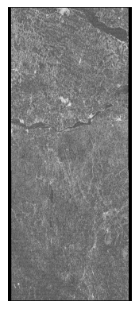

```python
im = plt.imread('20180916_Out_20180928_Out.diff.cc.bmp')
# Convert the image to grayscale
plt.imshow(im, cmap='gray')  # Display the grayscale image using 'gray' colormap
plt.axis('off')  # Turn off axis
plt.show()
```

```python
pg.geocode_back('20180916_Out_20180928_Out.diff.cc', 2574, '20180916.lt_fine', 'EQA.20180916_Out_20180928_Out.diff.cc', 17338, 0, 5, 0, '-', '-', 3)
```

```python
pg.data2geotiff('EQA.dem_par', 'EQA.20180916_Out_20180928_Out.diff.cc', 2, 'EQA.20180916_Out_20180928_Out.diff.cc.tif', '-')
```

# Phase Unwrapping

Since the phase is only known to modulo 2Pi in a wrapped interferogram, it must be unwrapped before it can be converted to geophysical units. Here, we are going to use the minimum cost flow (MCF) phase unwrapping method. MCF treats the phase unwrapping problem as a flow network, where each pixel is a node, and the phase differences between them are paths (or edges) in the network. The MCF algorithm assigns "costs" to these paths based on how much the phase changes between pixels. It then calculates the minimum cost flow through the network that results in a continuous unwrapped phase. In simple terms, the MCF algorithm tries to connect the phase inconsistencies by finding the cheapest way to connect the residues (Eineder et al., 1998).

```python
#Make a validity mask out of the coherence layer. The coherence threshold can be adjusted for each pair depending on how much phase noise there is.
#A threshold of .6 means that only pixels with coherence >= .6 will be unwrapped. I recommend starting with a threshold around here, looking at the results,
#and then adjusting.

pg.rascc_mask('20180916_Out_20180928_Out.diff.cc', '-', 2574, 1, 1, 0, 1, 1, .6)
```

```
cmd: C:\GAMMA_SOFTWARE-20240111\ISP\bin\rascc_mask 20180916_Out_20180928_Out.diff.cc - 2574 1 1 0 1 1 0.6

*** Generate phase unwrapping validity mask using correlation and intensity ***
*** Copyright 2023, Gamma Remote Sensing, v2.2 19-Apr-2023 clw/uw ***
default raster image output format: .bmp
input correlation data: 20180916_Out_20180928_Out.diff.cc
input image width: 2574
correlation data lines: 6122
correlation threshold: 0.600
range looks: 1   azimuth looks: 1
output image width: 2574   height: 6122
line 0
line 2000
line 4000
line 6000

output raster mask: 20180916_Out_20180928_Out.diff.cc_mask.bmp
width: 2574    lines: 6122

real elapsed time (s):      0.130
```

```
0
```

```python
#Here we are phase unwrapping using the minimum cost flow algorithm.

pg.mcf('20180916_Out_20180928_Out.diff','20180916_Out_20180928_Out.diff.cc','20180916_Out_20180928_Out.diff.cc_mask.bmp', '20180916_Out_20180928_Out.diff.unw', '2574', '-', '-', '-', '-', '-', '-', '-', '-', '-', '-', 0 )
```

```
cmd: C:\GAMMA_SOFTWARE-20240111\ISP\bin\mcf 20180916_Out_20180928_Out.diff 20180916_Out_20180928_Out.diff.cc 20180916_Out_20180928_Out.diff.cc_mask.bmp 20180916_Out_20180928_Out.diff.unw 2574 - - - - - - - - - - 0

*** Phase unwrapping using Minimum Cost Flow (MCF) on a triangular mesh ***
*** Copyright 2021, Gamma Remote Sensing, v2.8 clw/uw/cm 18-Aug-2021 ***
input interferogram file: 20180916_Out_20180928_Out.diff
weight file: 20180916_Out_20180928_Out.diff.cc
phase unwrapping mask file: 20180916_Out_20180928_Out.diff.cc_mask.bmp  raster format: 2
phase unwrapping mask width:  2574   height:  6122
unwrapped phase file: 20180916_Out_20180928_Out.diff.unw
interferogram data line width (samples): 2574
number of lines in the interferogram: 6122
number of lines in the weight file 6122

number of range samples to unwrap: 2443  number of azimuth lines to unwrap: 6095
number of range patches:       1   range patch width:    2443
number of azimuth patches:     1   azimuth patch width:  6095
patch overlap: 1024
phase reference point offset range: 1285  azimuth: 3061
init_flag 0: using reference point phase as starting phase value
memory allocation for output unwrapped phase buffer:     59.847 Mb
image segment range offset:        63  azimuth offset:       13
image segment range samples:     2443  azimuth lines:      6095
writing 13 blank lines at the beginning of the output file

***** PATCH: 1 *****
phase patch  (r,az):     1      1   r_offset:   63  az_offset:   13  lines read: 6095
weight patch (r,az):     1      1   r_offset:   63  az_offset:   13  lines read: 6095
mask patch   (r,az):     1      1   r_offset:   63  az_offset:   13  lines read: 6095
number of points to unwrap:      14890085
number of triangles:             29763096
number of edges:                 44653180
number triangles with one or more edges on the convex hull or enclosing an interior hole: 17070
mesh edges: 44653180
number of holes: 0
number of segments: 17072

number of network nodes: 29763097
maximum number of grounding arcs:     34144
maximum number of network arcs:    89306360

```

[output cut: 4931 more lines]

[output not shown]

```python
#Converting the unwrapped interferogram in line of site displacement to vertical displacement in (m).

pg.dispmap("20180916_Out_20180928_Out.diff.unw", '20180916.hgt', "20180916.slc.par", "20180916_Out_20180928_Out.off", "20180916_Out_20180928_Out.diff.unw.displ", 1)
```

Now to geocode and export the unwrapped interferogram to a geotiff.

```python
pg.raspwr('20180916_Out_20180928_Out.diff.unw.displ', 2574, '-', '-', '-', '-', '-', '-', '-', '20180916_Out_20180928_Out.diff.unw.displ.bmp')
```

```python
pg.geocode_back('20180916_Out_20180928_Out.diff.unw.displ', 2574, '20180916.lt_fine', 'EQA.20180916_Out_20180928_Out.diff.unw.displ', 17338, 0, 5, 0, '-', '-', 3)
```

```python
pg.data2geotiff('EQA.dem_par', 'EQA.20180916_Out_20180928_Out.diff.unw.displ', 2, 'EQA.20180916_Out_20180928_Out.diff.unw.displ.tif', '-')
```